# Classification of ECG Waveform

### Reading Data

```python
import numpy as np
import pandas as pd
dfn = pd.read_csv('./ptbdb_normal.csv',header=None)
print('Number of rows: ', len(dfn))
print('Number of columns: ', len(dfn.columns))
dfn.head()
```

```
Number of rows:  4046
Number of columns:  188
```

|  | 0 | 1 | 2 | 3 | 4 | 5 | 6 | 7 | 8 | 9 | ... | 178 | 179 | 180 | 181 | 182 | 183 | 184 | 185 | 186 | 187 |
| --- | --- | --- | --- | --- | --- | --- | --- | --- | --- | --- | --- | --- | --- | --- | --- | --- | --- | --- | --- | --- | --- |
| 0 | 1.000000 | 0.900324 | 0.358590 | 0.051459 | 0.046596 | 0.126823 | 0.133306 | 0.119125 | 0.110616 | 0.113047 | ... | 0.0 | 0.0 | 0.0 | 0.0 | 0.0 | 0.0 | 0.0 | 0.0 | 0.0 | 0.0 |
| 1 | 1.000000 | 0.794681 | 0.375387 | 0.116883 | 0.000000 | 0.171923 | 0.283859 | 0.293754 | 0.325912 | 0.345083 | ... | 0.0 | 0.0 | 0.0 | 0.0 | 0.0 | 0.0 | 0.0 | 0.0 | 0.0 | 0.0 |
| 2 | 0.909029 | 0.791482 | 0.423169 | 0.186712 | 0.000000 | 0.007836 | 0.063032 | 0.077002 | 0.074957 | 0.077342 | ... | 0.0 | 0.0 | 0.0 | 0.0 | 0.0 | 0.0 | 0.0 | 0.0 | 0.0 | 0.0 |
| 3 | 1.000000 | 0.478893 | 0.056760 | 0.064176 | 0.081289 | 0.072732 | 0.055619 | 0.048774 | 0.054478 | 0.041643 | ... | 0.0 | 0.0 | 0.0 | 0.0 | 0.0 | 0.0 | 0.0 | 0.0 | 0.0 | 0.0 |
| 4 | 1.000000 | 0.867238 | 0.201360 | 0.099349 | 0.141336 | 0.120934 | 0.108516 | 0.096393 | 0.093436 | 0.100828 | ... | 0.0 | 0.0 | 0.0 | 0.0 | 0.0 | 0.0 | 0.0 | 0.0 | 0.0 | 0.0 |

5 rows × 188 columns

```python
dfan = pd.read_csv('./ptbdb_abnormalx.csv',header=None)
print('Number of rows: ', len(dfn))
print('Number of columns: ', len(dfn.columns))
dfan.head()
```

```
Number of rows:  4046
Number of columns:  188
```

|  | 0 | 1 | 2 | 3 | 4 | 5 | 6 | 7 | 8 | 9 | ... | 178 | 179 | 180 | 181 | 182 | 183 | 184 | 185 | 186 | 187 |
| --- | --- | --- | --- | --- | --- | --- | --- | --- | --- | --- | --- | --- | --- | --- | --- | --- | --- | --- | --- | --- | --- |
| 0 | 0.932233 | 0.869679 | 0.886186 | 0.929626 | 0.908775 | 0.933970 | 0.801043 | 0.749783 | 0.687229 | 0.635100 | ... | 0.0 | 0.0 | 0.0 | 0.0 | 0.0 | 0.0 | 0.0 | 0.0 | 0.0 | 1.0 |
| 1 | 1.000000 | 0.606941 | 0.384181 | 0.254237 | 0.223567 | 0.276836 | 0.253430 | 0.184826 | 0.153349 | 0.121872 | ... | 0.0 | 0.0 | 0.0 | 0.0 | 0.0 | 0.0 | 0.0 | 0.0 | 0.0 | 1.0 |
| 2 | 1.000000 | 0.951613 | 0.923963 | 0.853303 | 0.791859 | 0.734255 | 0.672043 | 0.685100 | 0.670507 | 0.667435 | ... | 0.0 | 0.0 | 0.0 | 0.0 | 0.0 | 0.0 | 0.0 | 0.0 | 0.0 | 1.0 |
| 3 | 0.977819 | 0.899261 | 0.230129 | 0.032348 | 0.142329 | 0.223660 | 0.328096 | 0.367837 | 0.381701 | 0.389094 | ... | 0.0 | 0.0 | 0.0 | 0.0 | 0.0 | 0.0 | 0.0 | 0.0 | 0.0 | 1.0 |
| 4 | 0.935618 | 0.801661 | 0.805815 | 1.000000 | 0.722741 | 0.480789 | 0.454829 | 0.319834 | 0.266874 | 0.308411 | ... | 0.0 | 0.0 | 0.0 | 0.0 | 0.0 | 0.0 | 0.0 | 0.0 | 0.0 | 1.0 |

5 rows × 188 columns

### Let us plot some graphs

##### Plotting first 6 samples of normal and abnormal ECG

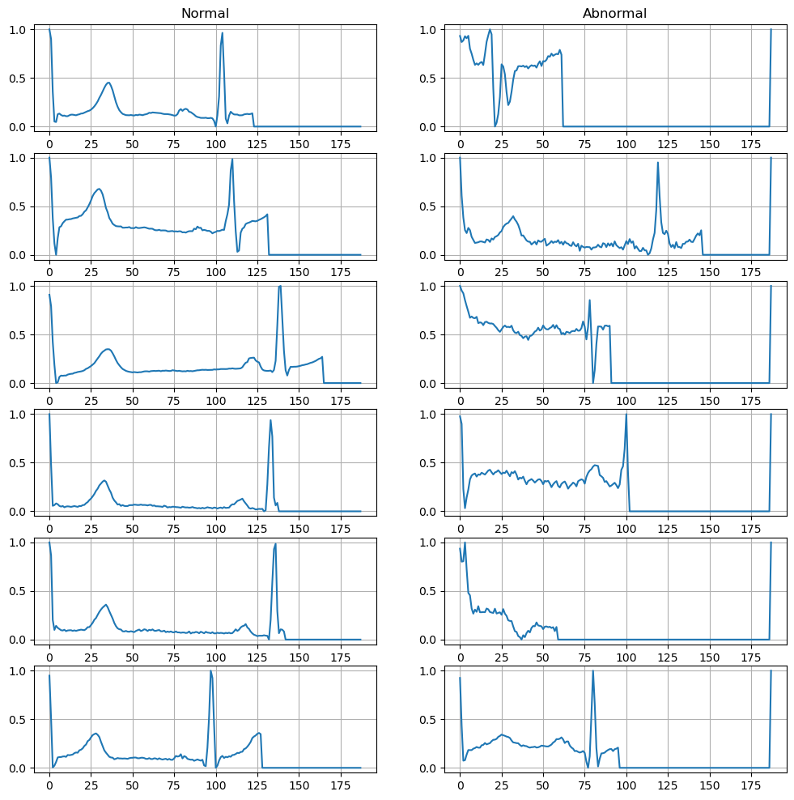

```python
import matplotlib.pyplot as plt
COLS = 2
ROWS = 6
ecg_fig, ax = plt.subplots(ROWS,COLS,figsize=(12,12))
for i in range(6):
    if(i==0):
        ax[i,0].set_title('Normal')
        ax[i,1].set_title('Abnormal')
    ax[i,0].plot(dfn.loc[i,:].values)
    ax[i,0].grid(visible=True, which='both', axis='both')
    ax[i,1].plot(dfan.loc[i,:].values)
    ax[i,1].grid(visible=True, which='both', axis='both')
plt.show()
```

##### Notice that last column is class label. 0 for normal and 1 for abnormal.

### Little dressing up of data for Model Building

1. Data is already pre-processed: size of samples is equal (cropped/zero padded wherever required)
2. We will add headers to the table
3. Will name the last column as 'Class': 0 for normal & 1 for abnormal

```python
colHeads = ['P'+str(i).zfill(3) for i in range(len(dfn.columns)-1)]+['Class']
#print(colHeads)
dfnh = pd.DataFrame(dfn.values,columns=colHeads)
print(len(dfnh))
dfnh.head()
```

```
4046
```

|  | P000 | P001 | P002 | P003 | P004 | P005 | P006 | P007 | P008 | P009 | ... | P178 | P179 | P180 | P181 | P182 | P183 | P184 | P185 | P186 | Class |
| --- | --- | --- | --- | --- | --- | --- | --- | --- | --- | --- | --- | --- | --- | --- | --- | --- | --- | --- | --- | --- | --- |
| 0 | 1.000000 | 0.900324 | 0.358590 | 0.051459 | 0.046596 | 0.126823 | 0.133306 | 0.119125 | 0.110616 | 0.113047 | ... | 0.0 | 0.0 | 0.0 | 0.0 | 0.0 | 0.0 | 0.0 | 0.0 | 0.0 | 0.0 |
| 1 | 1.000000 | 0.794681 | 0.375387 | 0.116883 | 0.000000 | 0.171923 | 0.283859 | 0.293754 | 0.325912 | 0.345083 | ... | 0.0 | 0.0 | 0.0 | 0.0 | 0.0 | 0.0 | 0.0 | 0.0 | 0.0 | 0.0 |
| 2 | 0.909029 | 0.791482 | 0.423169 | 0.186712 | 0.000000 | 0.007836 | 0.063032 | 0.077002 | 0.074957 | 0.077342 | ... | 0.0 | 0.0 | 0.0 | 0.0 | 0.0 | 0.0 | 0.0 | 0.0 | 0.0 | 0.0 |
| 3 | 1.000000 | 0.478893 | 0.056760 | 0.064176 | 0.081289 | 0.072732 | 0.055619 | 0.048774 | 0.054478 | 0.041643 | ... | 0.0 | 0.0 | 0.0 | 0.0 | 0.0 | 0.0 | 0.0 | 0.0 | 0.0 | 0.0 |
| 4 | 1.000000 | 0.867238 | 0.201360 | 0.099349 | 0.141336 | 0.120934 | 0.108516 | 0.096393 | 0.093436 | 0.100828 | ... | 0.0 | 0.0 | 0.0 | 0.0 | 0.0 | 0.0 | 0.0 | 0.0 | 0.0 | 0.0 |

5 rows × 188 columns

```python
dfanh = pd.DataFrame(dfan.values,columns=colHeads)
print(len(dfanh))
dfanh.head()
```

```
4046
```

|  | P000 | P001 | P002 | P003 | P004 | P005 | P006 | P007 | P008 | P009 | ... | P178 | P179 | P180 | P181 | P182 | P183 | P184 | P185 | P186 | Class |
| --- | --- | --- | --- | --- | --- | --- | --- | --- | --- | --- | --- | --- | --- | --- | --- | --- | --- | --- | --- | --- | --- |
| 0 | 0.932233 | 0.869679 | 0.886186 | 0.929626 | 0.908775 | 0.933970 | 0.801043 | 0.749783 | 0.687229 | 0.635100 | ... | 0.0 | 0.0 | 0.0 | 0.0 | 0.0 | 0.0 | 0.0 | 0.0 | 0.0 | 1.0 |
| 1 | 1.000000 | 0.606941 | 0.384181 | 0.254237 | 0.223567 | 0.276836 | 0.253430 | 0.184826 | 0.153349 | 0.121872 | ... | 0.0 | 0.0 | 0.0 | 0.0 | 0.0 | 0.0 | 0.0 | 0.0 | 0.0 | 1.0 |
| 2 | 1.000000 | 0.951613 | 0.923963 | 0.853303 | 0.791859 | 0.734255 | 0.672043 | 0.685100 | 0.670507 | 0.667435 | ... | 0.0 | 0.0 | 0.0 | 0.0 | 0.0 | 0.0 | 0.0 | 0.0 | 0.0 | 1.0 |
| 3 | 0.977819 | 0.899261 | 0.230129 | 0.032348 | 0.142329 | 0.223660 | 0.328096 | 0.367837 | 0.381701 | 0.389094 | ... | 0.0 | 0.0 | 0.0 | 0.0 | 0.0 | 0.0 | 0.0 | 0.0 | 0.0 | 1.0 |
| 4 | 0.935618 | 0.801661 | 0.805815 | 1.000000 | 0.722741 | 0.480789 | 0.454829 | 0.319834 | 0.266874 | 0.308411 | ... | 0.0 | 0.0 | 0.0 | 0.0 | 0.0 | 0.0 | 0.0 | 0.0 | 0.0 | 1.0 |

5 rows × 188 columns

### Check class labels before proceeding further

```python
print(set(dfnh['Class'].values))
print(set(dfanh['Class'].values))
```

```
{0.0}
{1.0}
```

### We want to use CNN (Convolutional Neural Network) for classifying, so let's first check tensorflow installation

```python
import tensorflow
print(tensorflow.__version__)
```

```
2.11.0
```

It's Tensorflow 2, so keras though an high level API on the Tensorflow, is part of Tensorflow 2.

### Let's first split the set into training, validation and test

1. We will first shuffle both normal and abnormal samples dataframes
2. Then we will pick 80% samples of each class for training and validation, keeping 20% for test
3. Out of 80% of training and validation, we keep 80% of that i.e. 64% (0.8*0.8 = 0.64) of total for training and remaining 16% of total for validation
4. Once we have training, validation and test set classwise, we merge them and create one training, one validation and one test set which contains equal samples of both classes

```python
dfnh = dfnh.sample(frac=1,random_state=5).reset_index(drop=True)
print(len(dfnh))
dfnh.head()
```

```
4046
```

|  | P000 | P001 | P002 | P003 | P004 | P005 | P006 | P007 | P008 | P009 | ... | P178 | P179 | P180 | P181 | P182 | P183 | P184 | P185 | P186 | Class |
| --- | --- | --- | --- | --- | --- | --- | --- | --- | --- | --- | --- | --- | --- | --- | --- | --- | --- | --- | --- | --- | --- |
| 0 | 1.000000 | 0.810383 | 0.239633 | 0.038303 | 0.065527 | 0.127572 | 0.135802 | 0.142450 | 0.145299 | 0.151630 | ... | 0.0 | 0.0 | 0.0 | 0.0 | 0.0 | 0.0 | 0.0 | 0.0 | 0.0 | 0.0 |
| 1 | 0.978470 | 0.664682 | 0.094366 | 0.013743 | 0.005955 | 0.054054 | 0.122309 | 0.138342 | 0.135593 | 0.143381 | ... | 0.0 | 0.0 | 0.0 | 0.0 | 0.0 | 0.0 | 0.0 | 0.0 | 0.0 | 0.0 |
| 2 | 1.000000 | 0.686918 | 0.413969 | 0.212639 | 0.181375 | 0.207761 | 0.213304 | 0.205322 | 0.206208 | 0.206874 | ... | 0.0 | 0.0 | 0.0 | 0.0 | 0.0 | 0.0 | 0.0 | 0.0 | 0.0 | 0.0 |
| 3 | 0.981328 | 0.828631 | 0.380083 | 0.172199 | 0.000000 | 0.027801 | 0.104564 | 0.125311 | 0.121162 | 0.128216 | ... | 0.0 | 0.0 | 0.0 | 0.0 | 0.0 | 0.0 | 0.0 | 0.0 | 0.0 | 0.0 |
| 4 | 0.979683 | 0.722540 | 0.177143 | 0.000000 | 0.116825 | 0.199365 | 0.234286 | 0.231746 | 0.254603 | 0.262222 | ... | 0.0 | 0.0 | 0.0 | 0.0 | 0.0 | 0.0 | 0.0 | 0.0 | 0.0 | 0.0 |

5 rows × 188 columns

```python
dfanh = dfanh.sample(frac=1,random_state=5).reset_index(drop=True)
print(len(dfanh))
dfanh.head()
```

```
4046
```

|  | P000 | P001 | P002 | P003 | P004 | P005 | P006 | P007 | P008 | P009 | ... | P178 | P179 | P180 | P181 | P182 | P183 | P184 | P185 | P186 | Class |
| --- | --- | --- | --- | --- | --- | --- | --- | --- | --- | --- | --- | --- | --- | --- | --- | --- | --- | --- | --- | --- | --- |
| 0 | 0.940517 | 0.979446 | 0.828714 | 0.633448 | 0.407350 | 0.244784 | 0.121457 | 0.052320 | 0.070383 | 0.053254 | ... | 0.0 | 0.0 | 0.0 | 0.0 | 0.0 | 0.0 | 0.0 | 0.0 | 0.0 | 1.0 |
| 1 | 1.000000 | 0.462723 | 0.168558 | 0.134117 | 0.254052 | 0.254862 | 0.266613 | 0.250000 | 0.242301 | 0.251621 | ... | 0.0 | 0.0 | 0.0 | 0.0 | 0.0 | 0.0 | 0.0 | 0.0 | 0.0 | 1.0 |
| 2 | 0.967301 | 0.329370 | 0.112961 | 0.077289 | 0.071344 | 0.026754 | 0.049346 | 0.038644 | 0.019025 | 0.030916 | ... | 0.0 | 0.0 | 0.0 | 0.0 | 0.0 | 0.0 | 0.0 | 0.0 | 0.0 | 1.0 |
| 3 | 1.000000 | 0.846457 | 0.707537 | 0.425197 | 0.232283 | 0.179415 | 0.170979 | 0.143982 | 0.136108 | 0.141170 | ... | 0.0 | 0.0 | 0.0 | 0.0 | 0.0 | 0.0 | 0.0 | 0.0 | 0.0 | 1.0 |
| 4 | 0.932377 | 0.905225 | 0.503586 | 0.366803 | 0.206455 | 0.122951 | 0.067623 | 0.033299 | 0.045082 | 0.043545 | ... | 0.0 | 0.0 | 0.0 | 0.0 | 0.0 | 0.0 | 0.0 | 0.0 | 0.0 | 1.0 |

5 rows × 188 columns

```python
Tn = int(0.64*len(dfnh))
Vn = int(0.16*len(dfnh))
Sn = len(dfnh) - Tn - Vn
print('Training Samples of each class should be: ',Tn)
print('Validation Samples of each class should be: ',Vn)
print('Test Samples of each class should be: ',Sn)
print('Total Samples of each class: ', (Tn+Vn+Sn))
```

```
Training Samples of each class should be:  2589
Validation Samples of each class should be:  647
Test Samples of each class should be:  810
Total Samples of each class:  4046
```

```python
dfnhT = dfnh[0:Tn].copy(deep=True).reset_index(drop=True)
dfnhV = dfnh[Tn:Tn+Vn].copy(deep=True).reset_index(drop=True)
dfnhS = dfnh[Tn+Vn:].copy(deep=True).reset_index(drop=True)
print(len(dfnhT))
print(len(dfnhV))
print(len(dfnhS))
```

```
2589
647
810
```

```python
dfanhT = dfanh[0:Tn].copy(deep=True).reset_index(drop=True)
dfanhV = dfanh[Tn:Tn+Vn].copy(deep=True).reset_index(drop=True)
dfanhS = dfanh[Tn+Vn:].copy(deep=True).reset_index(drop=True)
print(len(dfanhT))
print(len(dfanhV))
print(len(dfanhS))
```

```
2589
647
810
```

##### Also checking class distribution in each of the set: Training, Validation and Test

```python
from collections import Counter
dfT = pd.concat([dfnhT, dfanhT], ignore_index=True)
print(len(dfT))
print(Counter(dfT['Class'].values))
dfT.head()
```

```
5178
Counter({0.0: 2589, 1.0: 2589})
```

|  | P000 | P001 | P002 | P003 | P004 | P005 | P006 | P007 | P008 | P009 | ... | P178 | P179 | P180 | P181 | P182 | P183 | P184 | P185 | P186 | Class |
| --- | --- | --- | --- | --- | --- | --- | --- | --- | --- | --- | --- | --- | --- | --- | --- | --- | --- | --- | --- | --- | --- |
| 0 | 1.000000 | 0.810383 | 0.239633 | 0.038303 | 0.065527 | 0.127572 | 0.135802 | 0.142450 | 0.145299 | 0.151630 | ... | 0.0 | 0.0 | 0.0 | 0.0 | 0.0 | 0.0 | 0.0 | 0.0 | 0.0 | 0.0 |
| 1 | 0.978470 | 0.664682 | 0.094366 | 0.013743 | 0.005955 | 0.054054 | 0.122309 | 0.138342 | 0.135593 | 0.143381 | ... | 0.0 | 0.0 | 0.0 | 0.0 | 0.0 | 0.0 | 0.0 | 0.0 | 0.0 | 0.0 |
| 2 | 1.000000 | 0.686918 | 0.413969 | 0.212639 | 0.181375 | 0.207761 | 0.213304 | 0.205322 | 0.206208 | 0.206874 | ... | 0.0 | 0.0 | 0.0 | 0.0 | 0.0 | 0.0 | 0.0 | 0.0 | 0.0 | 0.0 |
| 3 | 0.981328 | 0.828631 | 0.380083 | 0.172199 | 0.000000 | 0.027801 | 0.104564 | 0.125311 | 0.121162 | 0.128216 | ... | 0.0 | 0.0 | 0.0 | 0.0 | 0.0 | 0.0 | 0.0 | 0.0 | 0.0 | 0.0 |
| 4 | 0.979683 | 0.722540 | 0.177143 | 0.000000 | 0.116825 | 0.199365 | 0.234286 | 0.231746 | 0.254603 | 0.262222 | ... | 0.0 | 0.0 | 0.0 | 0.0 | 0.0 | 0.0 | 0.0 | 0.0 | 0.0 | 0.0 |

5 rows × 188 columns

```python
dfV = pd.concat([dfnhV, dfanhV], ignore_index=True)
print(len(dfV))
print(Counter(dfV['Class'].values))
dfV.head()
```

```
1294
Counter({0.0: 647, 1.0: 647})
```

|  | P000 | P001 | P002 | P003 | P004 | P005 | P006 | P007 | P008 | P009 | ... | P178 | P179 | P180 | P181 | P182 | P183 | P184 | P185 | P186 | Class |
| --- | --- | --- | --- | --- | --- | --- | --- | --- | --- | --- | --- | --- | --- | --- | --- | --- | --- | --- | --- | --- | --- |
| 0 | 0.918624 | 0.833504 | 0.423902 | 0.066735 | 0.017365 | 0.044263 | 0.094654 | 0.075587 | 0.074566 | 0.073885 | ... | 0.0 | 0.0 | 0.0 | 0.0 | 0.0 | 0.0 | 0.0 | 0.0 | 0.0 | 0.0 |
| 1 | 1.000000 | 0.731690 | 0.171864 | 0.096447 | 0.184191 | 0.447426 | 0.403916 | 0.314721 | 0.343002 | 0.332125 | ... | 0.0 | 0.0 | 0.0 | 0.0 | 0.0 | 0.0 | 0.0 | 0.0 | 0.0 | 0.0 |
| 2 | 1.000000 | 0.861012 | 0.428116 | 0.228594 | 0.072083 | 0.080446 | 0.157308 | 0.180406 | 0.179610 | 0.185185 | ... | 0.0 | 0.0 | 0.0 | 0.0 | 0.0 | 0.0 | 0.0 | 0.0 | 0.0 | 0.0 |
| 3 | 1.000000 | 0.953247 | 0.380779 | 0.049870 | 0.000000 | 0.041039 | 0.070130 | 0.069091 | 0.066494 | 0.070130 | ... | 0.0 | 0.0 | 0.0 | 0.0 | 0.0 | 0.0 | 0.0 | 0.0 | 0.0 | 0.0 |
| 4 | 0.956797 | 0.957499 | 0.651563 | 0.294345 | 0.072006 | 0.000000 | 0.050931 | 0.088865 | 0.087812 | 0.077274 | ... | 0.0 | 0.0 | 0.0 | 0.0 | 0.0 | 0.0 | 0.0 | 0.0 | 0.0 | 0.0 |

5 rows × 188 columns

```python
dfS = pd.concat([dfnhS, dfanhS], ignore_index=True)
print(len(dfS))
print(Counter(dfS['Class'].values))
dfS.head()
```

```
1620
Counter({0.0: 810, 1.0: 810})
```

|  | P000 | P001 | P002 | P003 | P004 | P005 | P006 | P007 | P008 | P009 | ... | P178 | P179 | P180 | P181 | P182 | P183 | P184 | P185 | P186 | Class |
| --- | --- | --- | --- | --- | --- | --- | --- | --- | --- | --- | --- | --- | --- | --- | --- | --- | --- | --- | --- | --- | --- |
| 0 | 0.957152 | 0.690611 | 0.363579 | 0.154379 | 0.059231 | 0.221172 | 0.301197 | 0.310649 | 0.327032 | 0.350977 | ... | 0.0 | 0.0 | 0.0 | 0.0 | 0.0 | 0.0 | 0.0 | 0.0 | 0.0 | 0.0 |
| 1 | 1.000000 | 0.398978 | 0.052485 | 0.034371 | 0.059916 | 0.114724 | 0.154668 | 0.157919 | 0.152346 | 0.160242 | ... | 0.0 | 0.0 | 0.0 | 0.0 | 0.0 | 0.0 | 0.0 | 0.0 | 0.0 | 0.0 |
| 2 | 0.983407 | 0.885926 | 0.468444 | 0.304000 | 0.202963 | 0.187259 | 0.146074 | 0.128296 | 0.116444 | 0.112296 | ... | 0.0 | 0.0 | 0.0 | 0.0 | 0.0 | 0.0 | 0.0 | 0.0 | 0.0 | 0.0 |
| 3 | 1.000000 | 0.565443 | 0.344457 | 0.096774 | 0.000000 | 0.061179 | 0.121987 | 0.123841 | 0.123100 | 0.127920 | ... | 0.0 | 0.0 | 0.0 | 0.0 | 0.0 | 0.0 | 0.0 | 0.0 | 0.0 | 0.0 |
| 4 | 1.000000 | 0.973035 | 0.755393 | 0.489599 | 0.277735 | 0.187982 | 0.134438 | 0.112866 | 0.104777 | 0.098613 | ... | 0.0 | 0.0 | 0.0 | 0.0 | 0.0 | 0.0 | 0.0 | 0.0 | 0.0 | 0.0 |

5 rows × 188 columns

#### Shuffling the samples in each set. Though by default samples are shuffled in each epoch while training.

```python
dfT = dfT.sample(frac=1,random_state=5).reset_index(drop=True)
dfV = dfV.sample(frac=1,random_state=5).reset_index(drop=True)
dfS = dfS.sample(frac=1,random_state=5).reset_index(drop=True)
print(len(dfT))
print(len(dfV))
print(len(dfS))
```

```
5178
1294
1620
```

### Creating and Training a CNN Model for Classification

```python
import os
import tensorflow.keras as ks
from tensorflow.keras.layers import Conv1D, Activation, BatchNormalization, Input, Dropout, Dense, Flatten, MaxPool1D
from tensorflow.keras.callbacks import ModelCheckpoint,CSVLogger
from tensorflow.keras.optimizers import SGD,Adam
from numpy.random import seed
from tensorflow.keras.models import Model
from tensorflow.keras.losses import BinaryCrossentropy,CategoricalCrossentropy
from tensorflow.keras.metrics import CategoricalAccuracy
```

#### Understand the model architecture by tracking how layers are being added

```python
def get1DCNN(kSize = 7, TOTAL_PTS = 187, CHANNELS_INPUT = 1):
    seed(7)
    model = ks.Sequential()
    # Conv Layer 1
    model.add(Conv1D(filters=32, kernel_size=kSize, strides=1, input_shape=(TOTAL_PTS,CHANNELS_INPUT),padding='same'))
    model.add(BatchNormalization())
    model.add(Activation('relu'))
    model.add(MaxPool1D(pool_size=5,padding='same'))

    #Conv Layer 2
    model.add(Conv1D(filters=64, kernel_size=kSize, strides=1,padding='same'))
    model.add(BatchNormalization())
    model.add(Activation('relu'))
    model.add(MaxPool1D(pool_size=5,padding='same'))

    #Conv Layer 3
    model.add(Conv1D(filters=128, kernel_size=kSize, strides=1,padding='same'))
    model.add(BatchNormalization())
    model.add(Activation('relu'))
    model.add(MaxPool1D(pool_size=5,padding='same'))

    #Conv Layer 4
    model.add(Conv1D(filters=256, kernel_size=kSize, strides=1,padding='same'))
    model.add(BatchNormalization())
    model.add(Activation('relu'))
    model.add(MaxPool1D(pool_size=5,padding='same'))

    #Conv Layer 5
    model.add(Conv1D(filters=512, kernel_size=kSize, strides=1,padding='same'))
    model.add(BatchNormalization())
    model.add(Activation('relu'))
    model.add(MaxPool1D(pool_size=5,padding='same'))

    # Flatten followed by 6 dense layers
    model.add(Flatten())
    model.add(Dense(512, activation='relu'))
    model.add(Dropout(0.5))
    model.add(Dense(256, activation='relu'))
    model.add(Dropout(0.5))
    model.add(Dense(128, activation='relu'))
    model.add(Dense(64, activation='relu'))
    model.add(Dense(32, activation='relu'))
    model.add(Dense(2, activation="softmax"))
    model.compile(optimizer="adam", loss="categorical_crossentropy",metrics=CategoricalAccuracy())
    return model
```

#### Check the model summary. Verify input and output sizes.

```python
model = get1DCNN()
model.summary()
```

```
2023-04-13 16:18:19.805081: E tensorflow/compiler/xla/stream_executor/cuda/cuda_driver.cc:267] failed call to cuInit: CUDA_ERROR_NO_DEVICE: no CUDA-capable device is detected
```

```
Model: "sequential"
_________________________________________________________________
 Layer (type)                Output Shape              Param #
=================================================================
 conv1d (Conv1D)             (None, 187, 32)           256

 batch_normalization (BatchN  (None, 187, 32)          128
 ormalization)

 activation (Activation)     (None, 187, 32)           0

 max_pooling1d (MaxPooling1D  (None, 38, 32)           0
 )

 conv1d_1 (Conv1D)           (None, 38, 64)            14400

 batch_normalization_1 (Batc  (None, 38, 64)           256
 hNormalization)

 activation_1 (Activation)   (None, 38, 64)            0

 max_pooling1d_1 (MaxPooling  (None, 8, 64)            0
 1D)

 conv1d_2 (Conv1D)           (None, 8, 128)            57472

 batch_normalization_2 (Batc  (None, 8, 128)           512
 hNormalization)

 activation_2 (Activation)   (None, 8, 128)            0

 max_pooling1d_2 (MaxPooling  (None, 2, 128)           0
 1D)

 conv1d_3 (Conv1D)           (None, 2, 256)            229632

 batch_normalization_3 (Batc  (None, 2, 256)           1024
 hNormalization)

 activation_3 (Activation)   (None, 2, 256)            0
```

[output cut: 22 more lines]

```
 dropout_1 (Dropout)         (None, 256)               0

 dense_2 (Dense)             (None, 128)               32896

 dense_3 (Dense)             (None, 64)                8256

 dense_4 (Dense)             (None, 32)                2080

 dense_5 (Dense)             (None, 2)                 66

=================================================================
Total params: 1,661,026
Trainable params: 1,659,042
Non-trainable params: 1,984
_________________________________________________________________
```

#### Function to create data to feed to model. Creating numpy arrays from dataframe. Notice that output is one-hot encoded.

```python
from tensorflow.keras.utils import to_categorical
def createXY(df,onlyX=False,TOTAL_PTS=187,CHANNELS_INPUT=1,OUTPUT_DIM=2):
    N = len(df)
    X = np.zeros((N,TOTAL_PTS,CHANNELS_INPUT),dtype=np.float32)
    X[:,:,0] = df.iloc[:,0:TOTAL_PTS].values
    if not onlyX:
        Y = to_categorical(df['Class'].values)
        return X,Y
    else:
        return X
```

#### Check the dimension of input and output for all the sets

```python
X_TRAIN ,Y_TRAIN = createXY(dfT)
print(np.shape(X_TRAIN),np.shape(Y_TRAIN))
X_VALID ,Y_VALID = createXY(dfV)
print(np.shape(X_VALID),np.shape(Y_VALID))
X_TEST ,Y_TEST = createXY(dfS)
print(np.shape(X_TEST),np.shape(Y_TEST))
```

```
(5178, 187, 1) (5178, 2)
(1294, 187, 1) (1294, 2)
(1620, 187, 1) (1620, 2)
```

#### Function to train the model

```python
def trainModel(X_TRAIN, Y_TRAIN, X_VALID, Y_VALID, model, modelName, EPOCHS = 40, BATCH_SIZE = 32):
    destPath = './' + modelName + '/'
    if not os.path.isdir(destPath):
        os.mkdir(destPath)
    fpath = destPath + modelName
    csv_logger = CSVLogger(fpath+'.csv')
    model_checkpoint = ModelCheckpoint(fpath+'.h5', monitor='val_loss', verbose=1, save_best_only=True,
                                       save_weights_only=False, mode='auto', period=1)
    results = model.fit(x=X_TRAIN, y=Y_TRAIN, batch_size=BATCH_SIZE, epochs=EPOCHS, verbose=1,
             callbacks=[csv_logger,model_checkpoint], validation_data=(X_VALID, Y_VALID))
    print('Score on validation set')
    score = model.evaluate(X_VALID, Y_VALID, batch_size=BATCH_SIZE)
    print(score)
    return model,results,fpath
```

#### Model training

```python
model,results,fpath = trainModel(X_TRAIN, Y_TRAIN, X_VALID, Y_VALID, model, 'firstECG', EPOCHS = 40, BATCH_SIZE = 32)
```

```
WARNING:tensorflow:`period` argument is deprecated. Please use `save_freq` to specify the frequency in number of batches seen.
Epoch 1: val_loss improved from inf to 0.82337, saving model to ./firstECG/firstECG.h5
Epoch 2: val_loss did not improve from 0.82337
Epoch 3: val_loss did not improve from 0.82337
Epoch 4: val_loss improved from 0.82337 to 0.14067, saving model to ./firstECG/firstECG.h5
Epoch 5: val_loss did not improve from 0.14067
Epoch 6: val_loss did not improve from 0.14067
Epoch 7: val_loss improved from 0.14067 to 0.10754, saving model to ./firstECG/firstECG.h5
Epoch 8: val_loss did not improve from 0.10754
Epoch 9: val_loss did not improve from 0.10754
Epoch 10: val_loss did not improve from 0.10754
Epoch 11: val_loss did not improve from 0.10754
Epoch 12: val_loss did not improve from 0.10754
Epoch 13: val_loss did not improve from 0.10754
Epoch 14: val_loss did not improve from 0.10754
Epoch 15: val_loss did not improve from 0.10754
Epoch 16: val_loss did not improve from 0.10754
Epoch 17: val_loss did not improve from 0.10754
Epoch 18: val_loss improved from 0.10754 to 0.08585, saving model to ./firstECG/firstECG.h5
Epoch 19: val_loss did not improve from 0.08585
Epoch 20: val_loss did not improve from 0.08585
Epoch 21: val_loss did not improve from 0.08585
Epoch 22: val_loss did not improve from 0.08585
Epoch 23: val_loss did not improve from 0.08585
Epoch 24: val_loss did not improve from 0.08585
Epoch 25: val_loss did not improve from 0.08585
Epoch 26: val_loss did not improve from 0.08585
Epoch 27: val_loss did not improve from 0.08585
Epoch 28: val_loss did not improve from 0.08585
Epoch 29: val_loss did not improve from 0.08585
Epoch 30: val_loss did not improve from 0.08585
Epoch 31: val_loss did not improve from 0.08585
Epoch 32: val_loss improved from 0.08585 to 0.06136, saving model to ./firstECG/firstECG.h5
Epoch 33: val_loss did not improve from 0.06136
Epoch 34: val_loss did not improve from 0.06136
Epoch 35: val_loss did not improve from 0.06136
Epoch 36: val_loss improved from 0.06136 to 0.05710, saving model to ./firstECG/firstECG.h5
Epoch 37: val_loss did not improve from 0.05710
Epoch 38: val_loss did not improve from 0.05710
Epoch 39: val_loss did not improve from 0.05710
Epoch 40: val_loss did not improve from 0.05710
Score on validation set
[0.18058423697948456, 0.9644513130187988]
```

### Plotting the training curve

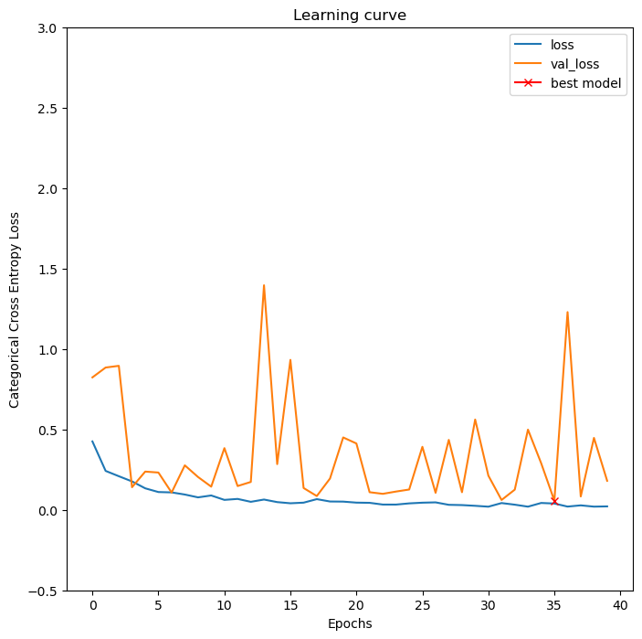

```python
import matplotlib.pyplot as plt
plt.figure(figsize=(8, 8))
plt.title("Learning curve")
plt.plot(results.history["loss"], label="loss")
plt.plot(results.history["val_loss"], label="val_loss")
plt.plot( np.argmin(results.history["val_loss"]), np.min(results.history["val_loss"]), marker="x", color="r", label="best model")
plt.xlabel("Epochs")
plt.ylabel("Categorical Cross Entropy Loss")
plt.ylim(-0.5,3.0)
plt.legend()
plt.savefig(fpath+'.png')
plt.show()
```

### Running the model on training, validation and test set

```python
Y_TRAIN_predict = model.predict(X_TRAIN)
Y_VALID_predict = model.predict(X_VALID)
Y_TEST_predict = model.predict(X_TEST)
print(np.shape(Y_TRAIN_predict))
print(np.shape(Y_VALID_predict))
print(np.shape(Y_TEST_predict))
```

```
(5178, 2)
(1294, 2)
(1620, 2)
```

#### The last layer is softmax, it gives us probability of each class

```python
print('Probability of both classes:', Y_TRAIN_predict[0:3])
print('Probability of abnormal class (Class 1):',Y_TRAIN_predict[0:3,1])
```

```
Probability of both classes: [[1.0872627e-01 8.9127380e-01]
 [9.9999994e-01 3.9412724e-19]
 [1.5341249e-01 8.4658748e-01]]
Probability of abnormal class (Class 1): [8.9127380e-01 3.9412724e-19 8.4658748e-01]
```

### Plotting RoC for each of the set, calculating AUC and choosing best threshold

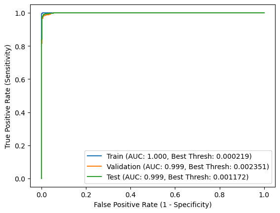

```python
import sklearn.metrics
tvals_train = Y_TRAIN[:,1]
pvals_train = Y_TRAIN_predict[:,1]
tvals_valid = Y_VALID[:,1]
pvals_valid = Y_VALID_predict[:,1]
tvals_test = Y_TEST[:,1]
pvals_test = Y_TEST_predict[:,1]

fpr_train,tpr_train,thresholds_train = sklearn.metrics.roc_curve(tvals_train,pvals_train)
fpr_valid,tpr_valid,thresholds_valid = sklearn.metrics.roc_curve(tvals_valid,pvals_valid)
fpr_test,tpr_test,thresholds_test = sklearn.metrics.roc_curve(tvals_test,pvals_test)

ind_train = np.argmax(tpr_train-fpr_train)
thresh_train = thresholds_train[ind_train]
auc_train = sklearn.metrics.auc(fpr_train, tpr_train)

ind_valid = np.argmax(tpr_valid-fpr_valid)
thresh_valid = thresholds_valid[ind_valid]
auc_valid = sklearn.metrics.auc(fpr_valid, tpr_valid)

ind_test = np.argmax(tpr_test-fpr_test)
thresh_test = thresholds_test[ind_test]
auc_test = sklearn.metrics.auc(fpr_test, tpr_test)

plt.plot(fpr_train,tpr_train,label='Train'+' (AUC: '+str("%.3f" % round(auc_train, 3))+', '
         + 'Best Thresh: '+str("%.6f" % round(thresh_train, 6))+')')
plt.plot(fpr_valid,tpr_valid,label='Validation'+' (AUC: '+str("%.3f" % round(auc_valid, 3))+', '
         + 'Best Thresh: '+str("%.6f" % round(thresh_valid, 6))+')')
plt.plot(fpr_test,tpr_test,label='Test'+' (AUC: '+str("%.3f" % round(auc_test, 3))+', '
         + 'Best Thresh: '+str("%.6f" % round(thresh_test, 6))+')')
plt.ylabel('True Positive Rate (Sensitivity)')
plt.xlabel('False Positive Rate (1 - Specificity)')
plt.legend()
plt.show()
```

### Classifying into normal and abnormal based on selected threshold. Obtaining confusion matrix.

###### Choosing threshold based on validation set and obtaining classification report

```python
train_predicted = 1*(pvals_train>=thresh_valid)
valid_predicted = 1*(pvals_valid>=thresh_valid)
test_predicted = 1*(pvals_test>=thresh_valid)
print(sklearn.metrics.classification_report(tvals_test, test_predicted))
```

```
              precision    recall  f1-score   support

         0.0       0.99      0.99      0.99       810
         1.0       0.99      0.99      0.99       810

    accuracy                           0.99      1620
   macro avg       0.99      0.99      0.99      1620
weighted avg       0.99      0.99      0.99      1620
```

#### Obtaining confusion matrix

```python
confusion_matrix_ecg = sklearn.metrics.confusion_matrix(tvals_test, test_predicted, labels=[0,1])
print(confusion_matrix_ecg)
```

```
[[802   8]
 [ 10 800]]
```

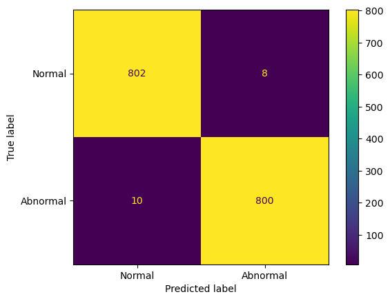

```python
cm_ecg = sklearn.metrics.ConfusionMatrixDisplay(confusion_matrix_ecg,display_labels=['Normal','Abnormal'])
cm_ecg.plot()
plt.show()
```

### Assignment: Try to achieve same results by model with lesser parameters. Also try to improve results of the model.